# Guests · the filter popup

Prototype for approval — before (shipped, 390 px) vs after. Every option is kept; only the presentation changes. Nothing in the app has been changed.

## Before — shipped

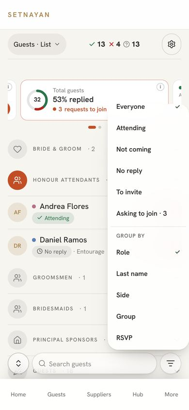

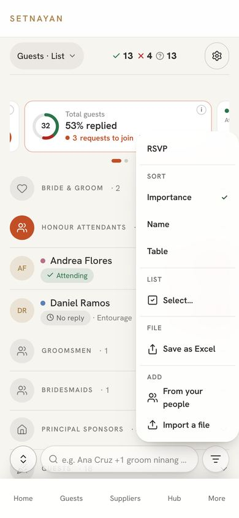

One list of 18 rows that scrolls inside itself, opened from the ≡ at the top of the thumb row. Show alone is 6 rows; Sort, Select, Excel and the add ways sit below the fold. No count of what is applied and no "Clear all". (Left: top of the list. Right: scrolled to its end.)

## After — proposed

SETNAYAN

Bride & Groom · 2

Honour attendants · 2

**Andrea Flores**

**Daniel Ramos**

Groomsmen · 1

### Show & sort

Who you see

Show

Which guests are in the list

"To invite" is everyone not sent an invitation yet. "Asking to join" opens the requests waiting for your yes.

+1s

Only seats a guest brings

Shown only when your list has +1s. "No name yet" is a seat still waiting for its guest's name. A new Group by clears this.

How it is laid out

Group by

The headings of the list

Side appears only when your event has sides. The Map shares this choice (it has no Last name).

Sort

The order inside each heading

Importance is the page's own order — the couple first, then the entourage. A +1 always stays beside their guest.

Do more

- Each set of choices is ONE dropdown (Show · +1s · Group by · Sort) — tap one to open its list; a picked one reads in terracotta.
- Frames only on things you press; topics are split by a divider.
- Title + one line; the rest is behind ⓘ.
- The sheet rises from the bottom — every control is in thumb reach; the count of applied choices sits in the title, Clear all and Done at the foot.
- Select, Excel and the two add ways stay — as the "Do more" actions, not mixed into the choices.